# 2-research_analysis

## Research Areas Analysis Using Graph Data and Large Language Models

### Donato Riccio

[figure not shown]

```
{'type': 'paper',
 'community': 1,
 'hub_score': 7.32494331326724e-05,
 'authority_score': 2.8217589803258444e-06}
```

# Power law fit

The close alignment between the two lines over most of the range indicates that the power law is a good fit for the data. However, there are some deviations at the highest degree values.

```
Graph already in memory
```

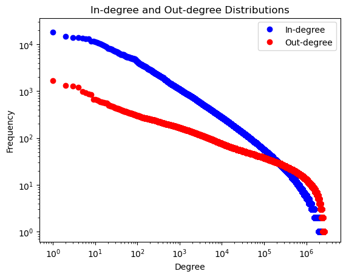

```
Values less than or equal to 0 in data. Throwing out 0 or negative values
Calculating best minimal value for power law fit
Values less than or equal to 0 in data. Throwing out 0 or negative values
Calculating best minimal value for power law fit
```

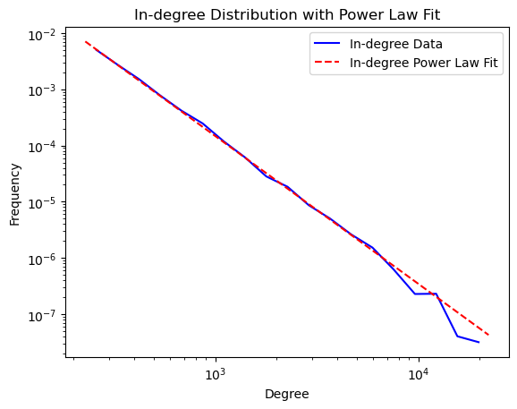

```
Log-likelihood ratio for in-degree: 2904.1246981944305
p-value for in-degree: 2.1069363477657624e-65
```

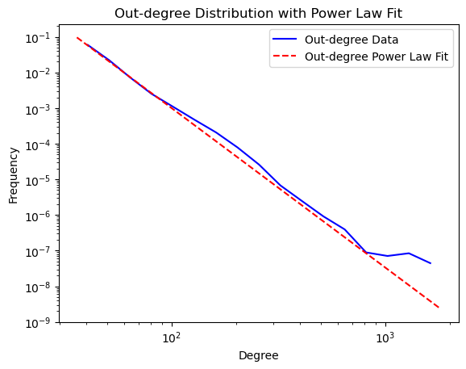

```
Log-likelihood ratio for out-degree: 10841.798850400397
p-value for out-degree: 0.0
```

The results of the distribution comparison for both in-degree and out-degree distributions indicate a very strong preference for the power law distribution over the exponential distribution. The log-likelihood ratios for in-degree and out-degree are both significantly positive, suggesting that the power law distribution fits the data much better than the exponential distribution. The p-values are extremely small, indicating that these differences are statistically significant.

These results confirm that both the in-degree and out-degree distributions in the network exhibit a scale-free characteristic, where a few nodes have a very high degree, while most nodes have a low degree, fitting a power law model far better than an exponential one.

# Modularity Score for the Given Partition

The modularity score is a key metric used to evaluate the quality of the partitioning of a network into communities. It measures the strength of the division of the network into modules (also called communities), where higher values indicate a stronger community structure.

```
There are 52 communities (research areas) with more than 10 nodes (papers).
```

```
Graph already in memory
3027780 3027780 3027780
3027780 3027780 3027780
Modularity for the given partition: 0.7324
```

- A modularity score of 0.7324 suggests a very good partitioning of the network, indicating that the nodes within the same community are highly interconnected compared to nodes in different communities.
- Generally, a modularity score above 0.3 is considered significant, and scores above 0.7 indicate a very strong community structure.

This high modularity score reflects that the identified communities in our citation network are well-defined, with dense connections within communities and sparse connections between them. This validates the effectiveness of our community detection approach using the Infomap algorithm.

# Topic detection with GPT-4o

In this section, we utilize the capabilities of GPT-4 to detect and label topics within the identified research communities. By analyzing titles of papers within each community, GPT-4 can provide descriptive labels that encapsulate the core themes of the research areas.

| community | topic | description |
| --- | --- | --- |
| 1 | Deep Learning for Object Detection and Image Recognition | The research community is predominantly focused on advancements in computer vision and machine learning, particularly using deep learning techniques for object detection and image recognition. Researc… |
| 2 | Advances in AI and machine learning for NLP and multimodal data | The research community predominantly focuses on advancements in machine learning and artificial intelligence, with particular emphasis on natural language processing (NLP), machine translation, and im… |
| 4 | Machine Learning for Image Classification and Analysis | The research community is focused on machine learning techniques, particularly in the context of image classification and analysis. Key problems addressed include handling class imbalance, dealing wit… |
| 3 | Machine Learning in Software Engineering | The research community focuses on applying machine learning and deep learning techniques to software engineering and programming. Key problems addressed include defect prediction, bug localization, co… |
| 6 | Combining deep learning and augmented reality for advanced applications | The research community appears to be focused on the intersection of machine learning, particularly deep learning, and augmented reality (AR). This area addresses several key challenges such as improvi… |
| 5 | Optimized machine learning for large-scale, distributed data processing | The primary focus of this research community is on the development and optimization of machine learning frameworks and algorithms for large-scale data processing, particularly in cloud and edge comput… |
| 8 | Deep learning and reinforcement learning in robotics | The prominent focus of this research community centers on the integration of deep learning and reinforcement learning techniques in robotic systems, particularly for applications in autonomous driving… |
| 9 | Machine learning in wireless communication systems | The research area revolves around the application of machine learning techniques to wireless communication systems. This community investigates how deep learning, neural networks, and other machine le… |
| 10 | Optimizing computational systems for deep learning and HPC. | The research community primarily focuses on optimizing large-scale computational systems, particularly in the context of deep learning, computer vision, and high-performance computing (HPC) applicatio… |
| 7 | Privacy, Security, and Machine Learning | This research community is concentrated on the intersection of privacy, security, and machine learning, specifically focusing on the protection of sensitive data and the detection of malicious activit… |
| 13 | Machine Learning for Image Classification and Evolutionary Algorithms. | The research community represented in this citation network predominantly focuses on machine learning techniques applied to image classification, evolutionary algorithms, and optimization. The main pr… |
| 11 | Multimedia information retrieval and similarity search | The research community's main focus is on advancing techniques for multimedia information retrieval and similarity search within vast datasets, including images, videos, and other multimedia content. … |
| 12 | Human activity recognition using machine learning and sensor fusion | The research community appears to be focused on human activity and behavior recognition leveraging machine learning, particularly deep learning, and sensor fusion techniques. Key problems in this area… |
| 15 | Machine learning and AI for autonomous and distributed systems | The research community in the given paper citation network predominantly focuses on advanced techniques in machine learning and artificial intelligence applied to a broad range of real-time and distri… |
| 14 | Optimizing complex problems with advanced machine learning. | The research community is primarily focused on leveraging machine learning techniques to solve complex optimization problems, both in theoretical and practical domains. This includes a variety of algo… |
| 16 | Advanced machine learning for audio and speech recognition | This research community focuses on leveraging machine learning, particularly deep learning methods, to enhance various aspects of audio and speech recognition. The primary challenges addressed include… |
| 18 | Deep learning in computational biology and chemoinformatics | The research community appears to be focused on harnessing machine learning, particularly deep learning techniques, to advance computational biology and chemoinformatics. Main problems tackled include… |
| 17 | Deep Learning in Computer Graphics and Visualization | The research community focuses extensively on the intersection of deep learning and computer graphics, with a major emphasis on image and surface reconstruction, rendering techniques, and artistic sty… |
| 21 | Deep learning for PDEs and uncertainty quantification | The research community identified focuses on leveraging machine learning techniques, particularly deep learning, to tackle various computational challenges in the fields of partial differential equati… |
| 19 | Applying deep learning to neuroscience and brain-computer interfaces. | This research community is primarily focused on the intersection of machine learning and neuroscience, particularly the application of deep learning techniques to brain-computer interfaces (BCIs), bra… |
| 23 | Advanced machine learning for remote sensing image analysis | The research community described in the hub and authority list is primarily focused on the development of advanced machine learning and deep learning techniques for analyzing and processing remote sen… |
| 24 | Optimizing spiking neural networks for neuromorphic computing. | The research community is primarily focused on the development and optimization of spiking neural networks (SNNs) and their applications in neuromorphic computing. Spiking neural networks aim to mimic… |
| 22 | Natural computation and machine learning algorithms | This research community is primarily focused on the intersection of machine learning, computational models, and natural computation. Their work extensively explores the application of neural networks,… |
| 20 | Machine learning for steganography and steganalysis | The research community appears to be focused on advanced techniques in steganography and steganalysis using machine learning, particularly deep learning methods such as convolutional neural networks (… |
| 26 | Advanced sensing and data processing in biomedical applications. | The research community described in the provided titles seems to be primarily focused on advanced sensing and data processing techniques, particularly in the context of neural, biomedical, and imaging… |
| 25 | Data compression and similarity measurement techniques | This research community predominantly focuses on data compression and similarity measurement techniques, with applications spanning across various domains such as image processing, text analysis, and … |
| 27 | Error-correcting codes and their applications | The research community in question primarily focuses on the field of error-correcting codes and their applications. This area aims to develop methods to identify and correct errors in data transmissio… |
| 28 | Advanced Machine Learning and Simulation for Complex Systems | This research community focuses on the use of advanced machine learning and simulation techniques to model, predict, and analyze complex systems across various domains such as healthcare, manufacturin… |
| 31 | Reliability optimization and predictive maintenance using machine learning | The research community focuses on enhancing reliability, prediction, and optimization in complex industrial and technological systems using advanced machine learning, probabilistic models, and optimiz… |
| 32 | Machine learning in cardiovascular diagnostics | The primary focus of this research community is on the application of machine learning and deep learning techniques to cardiovascular health, particularly in the analysis of electrocardiogram (ECG) si… |
| 29 | Mathematical optimization and geometric theorem proving using machine learning. | The research community highlighted in this citations network appears to be deeply focused on the intersection of mathematical optimization, geometric theorem proving, and machine learning. Central top… |
| 30 | Multi-object tracking and data association techniques. | The research community represented by these hubs and authorities focuses on the development and enhancement of methods for multi-object tracking, navigation, and data association in various fields inc… |
| 33 | Adaptive filtering and robust estimation under non-Gaussian noise. | The primary research focus of this community is on advancing adaptive filtering and robust estimation techniques in the presence of non-Gaussian noise. These researchers are particularly interested in… |
| 34 | Machine learning-enhanced engineering and design optimization | The research community is focused on utilizing machine learning and artificial intelligence to enhance various aspects of design and engineering, particularly within the realms of architecture, constr… |
| 35 | Machine learning for radar-based detection and classification | The research community primarily focuses on leveraging machine learning techniques, particularly deep learning, for radar-based detection and classification of various underground and above-ground ano… |
| 36 | Design and optimization of digital filters and differentiators | The primary focus of this research community is on the design, analysis, and implementation of digital filters and differentiators, with a particular emphasis on fractional calculus methods. These stu… |
| 37 | Mathematical logic and theoretical computer science. | The research community appears to be focused on the field of mathematical logic and theoretical computer science. Key topics include model theory, set theory, recursion theory, and computability theor… |
| 38 | Historical and technical development of computing technologies. | The primary research focus of this academic community revolves around the historical, theoretical, and technical development of computing technologies and their implications in various domains. Influe… |
| 40 | Nondestructive testing using advanced sensing technologies and algorithms. | The research community is primarily focused on the development and optimization of nondestructive testing (NDT) methods to inspect and monitor various materials and structures. Main problems addressed… |
| 39 | Computational modeling of biological processes and tumor growth. | The primary research area of this community revolves around computational modeling and simulation of biological processes, particularly focusing on organogenesis, tumor growth, and cellular dynamics. … |
| 41 | Special functions and their applications in scientific fields. | The research community appears to concentrate on advanced mathematical functions and their applications across various scientific fields. Notable focuses include the gamma and psi functions, hypergeom… |
| 42 | Fractal generation and visualization in complex dynamic systems. | This research community is predominantly focused on the computational generation, analysis, and visualization of fractal patterns and complex dynamic systems. Fractals are intricate geometric shapes t… |
| 44 | Reliability and optimization of microelectronic packaging systems. | The research community represented in the list of hubs and authorities is primarily focused on the reliability, structural integrity, and performance optimization of microelectronic packaging systems.… |
| 45 | Advances in survey sampling techniques and estimation methods. | The primary research focus of this community is on survey sampling techniques, particularly in contexts where traditional data collection faces challenges such as missing data, nonresponse, or the nee… |
| 43 | Fixed point theorems in generalized metric spaces | The research area this community is focused on revolves around the development and analysis of fixed point theorems, primarily in the context of metric, partial metric, and cone metric spaces. These t… |
| 47 | Thermodynamic principles in complex biological and mechanical systems. | This research community is primarily focused on understanding the principles and applications of thermodynamics, particularly in the context of complex systems, both biological and mechanical. The mai… |
| 46 | Non-linear and rational difference equations | The research community appears to be heavily focused on the study of non-linear and rational difference equations, particularly their stability, global behaviors, and oscillatory nature. These equatio… |
| 48 | Biomechanical modeling of skeletal structures and tissues | The primary focus of this research community lies in the computational and mathematical modeling of biomechanical systems, particularly involving bones, joints, and soft tissues. Researchers in this a… |
| 49 | Braille recognition and translation technology | This research community is primarily focused on the development and improvement of technologies for Braille recognition, translation, and accessibility. Key problems tackled within this area include t… |
| 50 | Mathematical and computational modeling of combat scenarios. | This research community primarily focuses on developing mathematical and computational models to understand and predict outcomes in various combat scenarios, integrating principles from Lanchester's c… |
| 51 | Statistical methods for comparing treatment means under heteroscedasticity. | The research community is primarily focused on statistical methods for testing the equivalence and comparison of treatment means under varied conditions, such as unequal variances (heteroscedasticity)… |
| 54 | High-entropy alloys and their diverse properties | The research community is primarily focused on the study of high-entropy alloys (HEAs) and their diverse properties, particularly their microstructures, mechanical, electrical, and corrosion behaviors… |

Now that we have topic and description for each community, we'll analyze the number of papers along with their growth rates.

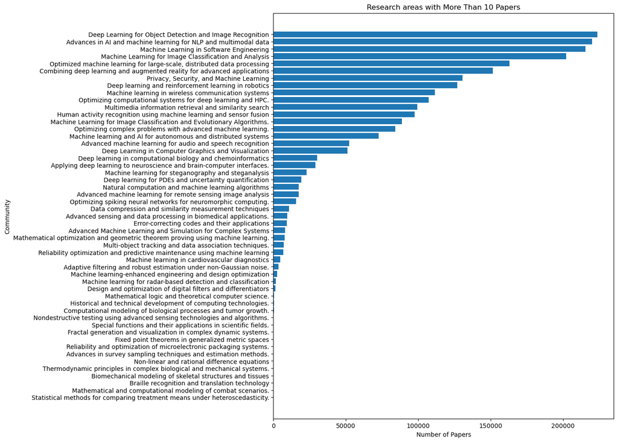

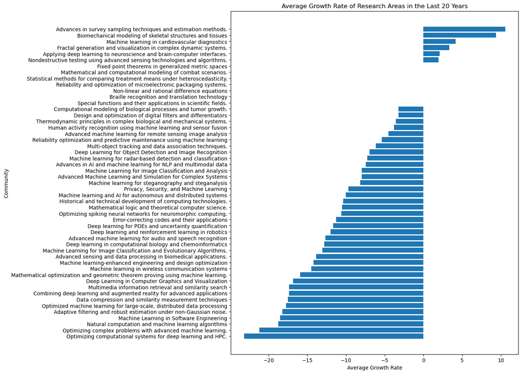

# Community profile

```
Graph already in memory
```

Deep Learning for Object Detection and Image Recognition

The research community is predominantly focused on advancements in computer vision and machine learning, particularly using deep learning techniques for object detection and image recognition. Researchers in this field aim to develop robust and efficient algorithms capable of accurately detecting, classifying, and segmenting objects within images and videos. Key problems addressed include improving the accuracy and speed of object recognition systems, handling diverse and complex visual data, and developing architectures like Convolutional Neural Networks (CNNs), Residual Networks (ResNets), and Fully Convolutional Networks (FCNs). Methods such as feature extraction, image segmentation, and various optimization techniques are central to these advancements. The ultimate goal is to create systems that can rival or surpass human performance in visual tasks, enabling applications ranging from autonomous driving to medical image analysis and multimedia analytics.  
**Community ID**: 1  
**Number of Papers**: 223831

**Coverage index** 0.1643

**Growth rate (last 20 years)** -6.9632

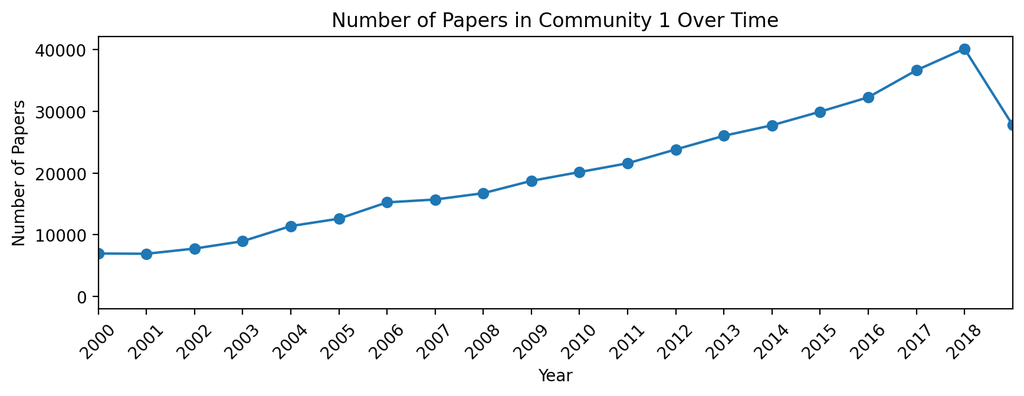

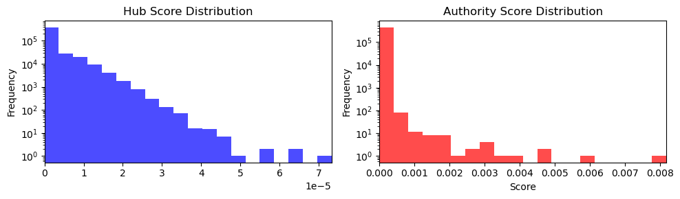

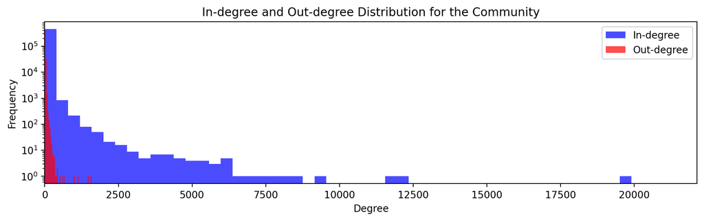

**Top 5 hubs in the community:**

- **Deep Learning for Generic Object Detection: A Survey** - Li Liu;Wanli Ouyang;Xiaogang Wang;Paul W. Fieguth;Jie Chen;Xinwang Liu;Matti Pietikäinen - *International Journal of Computer Vision* - 2019

- **Deep Learning for Generic Object Detection: A Survey.** - Li Liu;Wanli Ouyang;Xiaogang Wang;Paul Fieguth;Jie Chen;Xinwang Liu;Matti Pietikäinen - *arXiv: Computer Vision and Pattern Recognition* - 2018

- **Recent Advances in Convolutional Neural Networks** - Jiuxiang Gu;Zhenhua Wang;Jason Kuen;Lianyang Ma;Amir Shahroudy;Bing Shuai;Ting Liu;Xingxing Wang;Gang Wang - *arXiv: Computer Vision and Pattern Recognition* - 2015

- **Object Detection With Deep Learning: A Review** - Zhong-Qiu Zhao;Peng Zheng;Shou-Tao Xu;Xindong Wu - *IEEE Transactions on Neural Networks* - 2019

- **Recent Advances in Object Detection in the Age of Deep Convolutional Neural Networks** - Shivang Agarwal;Jean Ogier Du Terrail;Frédéric Jurie - *arXiv: Computer Vision and Pattern Recognition* - 2019

**Top 5 authorities:**

- **Distinctive Image Features from Scale-Invariant Keypoints** - David G. Lowe - *International Journal of Computer Vision* - 2004

- **VERY DEEP CONVOLUTIONAL NETWORKS FOR LARGE-SCALE IMAGE RECOGNITION** - Karen Simonyan;Andrew Zisserman - *arXiv: Computer Vision and Pattern Recognition* - 2014

- **ImageNet Classification with Deep Convolutional Neural Networks** - Alex Krizhevsky;Ilya Sutskever;Geoffrey E. Hinton - *Neural Information Processing Systems* - 2012

- **Histograms of oriented gradients for human detection** - N. Dalal;B. Triggs - *Computer Vision and Pattern Recognition* - 2005

- **Deep Residual Learning for Image Recognition** - Kaiming He;Xiangyu Zhang;Shaoqing Ren;Jian Sun - *Computer Vision and Pattern Recognition* - 2016

Advances in AI and machine learning for NLP and multimodal data

The research community predominantly focuses on advancements in machine learning and artificial intelligence, with particular emphasis on natural language processing (NLP), machine translation, and image data analysis. This area addresses various key challenges including understanding and generating human language, improving semantic representations, and leveraging multimodal data for tasks such as translation and sentiment analysis. The community extensively explores deep learning architectures such as convolutional neural networks (CNNs), recurrent neural networks (RNNs), and attention mechanisms. These methodologies are applied to diverse problems, ranging from automatic translation and sentiment analysis to emergency situation awareness through social media image processing. The ultimate objectives are to enhance the performance and interpretability of AI systems in human-centric applications, optimize their learning processes, and extend their capabilities to handle complex multimodal data streams effectively.  
**Community ID**: 2  
**Number of Papers**: 220034

**Coverage index** 0.0683

**Growth rate (last 20 years)** -7.4259

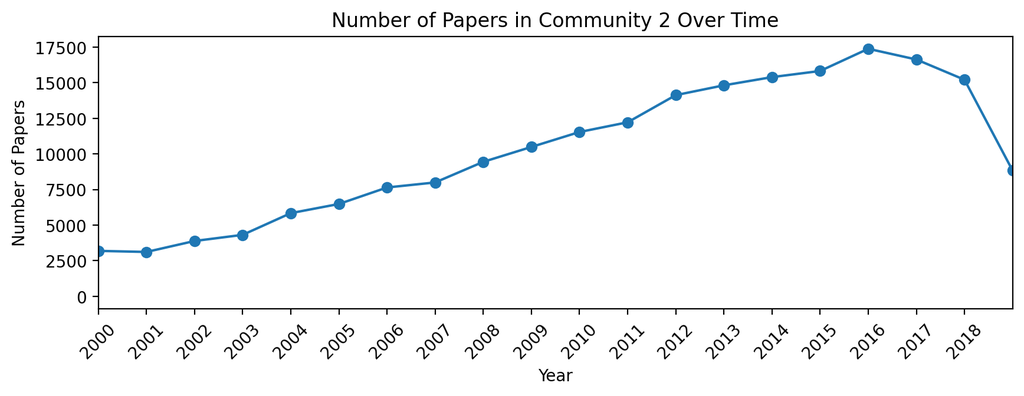

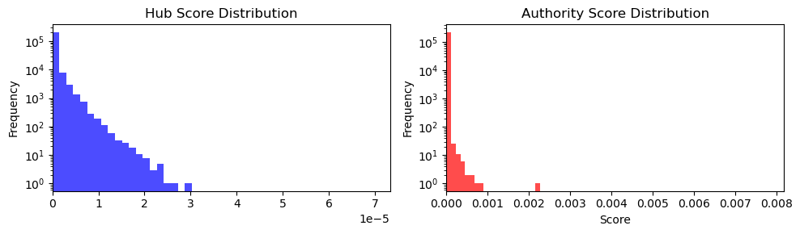

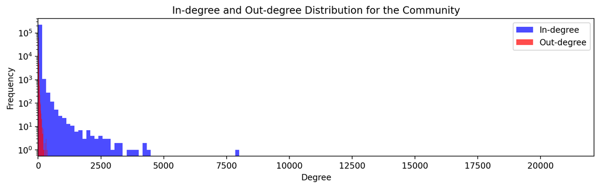

**Top 5 hubs in the community:**

- **Damage Assessment from Social Media Imagery Data During Disasters** - Dat T. Nguyen;Ferda Ofli;Muhammad Imran;Prasenjit Mitra - *Advances in Social Networks Analysis and Mining* - 2017

- **Content-based artwork recommendation: integrating painting metadata with neural and manually-engineered visual features** - Pablo Messina;Vicente Dominguez;Denis Parra;Christoph Trattner;Alvaro Soto - *User Modeling and User-adapted Interaction* - 2019

- **Intrinsic Image Popularity Assessment** - Keyan Ding;Kede Ma;Shiqi Wang - *arXiv: Multimedia* - 2019

- **Heterogeneous Network Embedding via Deep Architectures** - Shiyu Chang;Wei Han;Jiliang Tang;Guo-Jun Qi;Charu C. Aggarwal;Thomas S. Huang - *Knowledge Discovery and Data Mining* - 2015

- **Fine-Grained Land Use Classification at the City Scale Using Ground-Level Images** - Yi Zhu;Xueqing Deng;Shawn Newsam - *IEEE Transactions on Multimedia* - 2019

**Top 5 authorities:**

- **Long short-term memory** - Sepp Hochreiter;Jürgen Schmidhuber - *Neural Computation* - 1997

- **Latent dirichlet allocation** - David M. Blei;Andrew Y. Ng;Michael I. Jordan - *Journal of Machine Learning Research* - 2003

- **Neural Machine Translation by Jointly Learning to Align and Translate** - Dzmitry Bahdanau;Kyunghyun Cho;Yoshua Bengio - *arXiv: Computation and Language* - 2014

- **Glove: Global Vectors for Word Representation** - Jeffrey Pennington;Richard Socher;Christopher Manning - *Empirical Methods in Natural Language Processing* - 2014

- **Efficient Estimation of Word Representations in Vector Space** - Tomas Mikolov;Kai Chen;Greg S. Corrado;Jeffrey Dean - *International Conference on Learning Representations* - 2013

Machine Learning in Software Engineering

The research community focuses on applying machine learning and deep learning techniques to software engineering and programming. Key problems addressed include defect prediction, bug localization, code comprehension, and automatic code generation. Methods utilized range from convolutional neural networks (CNNs), attention networks, and autoencoders to neural machine translation and dual-language vector spaces. This emerging area aims to enhance the automation and intelligence of software development processes, reduce software errors, and improve code quality and maintainability. The ultimate goal is to develop more sophisticated tools that can assist programmers, extract meaningful patterns from large codebases, and facilitate the creation of more reliable and efficient software systems.  
**Community ID**: 3  
**Number of Papers**: 215456

**Coverage index** 0.0707

**Growth rate (last 20 years)** -18.4983

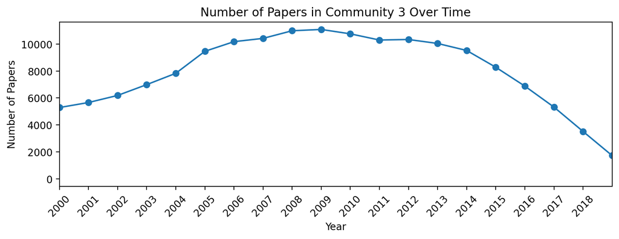

[figure not shown]

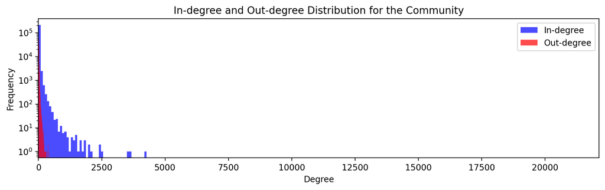

**Top 5 hubs in the community:**

- **Code Localization in Programming Screencasts** - Mohammad Alahmadi;Abdulkarim Khormi;Biswas Parajuli;Jonathan Hassel;Sonia Haiduc;Piyush Kumar - *Empirical Software Engineering* - 2020

- **Identifying implementation bugs in machine learning based image classifiers using metamorphic testing** - Anurag Dwarakanath;Manish Ahuja;Samarth Sikand;Raghotham M. Rao;R. P. Jagadeesh Chandra Bose;Neville Dubash;Sanjay Podder - *International Symposium on Software Testing and Analysis* - 2018

- **An Inception Architecture-Based Model for Improving Code Readability Classification** - Qing Mi;Jacky Keung;Yan Xiao;Solomon Mensah;Xiupei Mei - *Evaluation and Assessment in Software Engineering* - 2018

- **StaQC: A Systematically Mined Question-Code Dataset from Stack Overflow** - Ziyu Yao;Daniel Weld;Wei-Peng Chen;Huan Sun - *The Web Conference* - 2018

- **From UI design image to GUI skeleton: a neural machine translator to bootstrap mobile GUI implementation** - Chunyang Chen;Ting Su;Guozhu Meng;Zhenchang Xing;Yang Liu - *International Conference on Software Engineering* - 2018

**Top 5 authorities:**

- **Neural GPUs Learn Algorithms** - Łukasz Kaiser;Ilya Sutskever - *arXiv: Learning* - 2015

- **Supporting user-oriented analysis for multi-view domain-specific visual languages** - Esther Guerra;Juan de Lara;Alessio Malizia;Paloma Díaz - *Information & Software Technology* - 2009

- **Neural Programmer: Inducing Latent Programs with Gradient Descent** - Arvind Neelakantan;Quoc V. Le;Ilya Sutskever - *arXiv: Learning* - 2015

- **Neural Programmer-Interpreters** - Scott Reed;Nando de Freitas - *arXiv: Learning* - 2015

- **Benchmarking Classification Models for Software Defect Prediction: A Proposed Framework and Novel Findings** - S. Lessmann;B. Baesens;C. Mues;S. Pietsch - *IEEE Transactions on Software Engineering* - 2008

Machine Learning for Image Classification and Analysis

The research community is focused on machine learning techniques, particularly in the context of image classification and analysis. Key problems addressed include handling class imbalance, dealing with noisy labels, multi-view learning, and the integration of deep learning models for robust image recognition and clustering. Methods employed involve semi-supervised learning, ensemble methods, kernel-based approaches, and advanced neural network architectures such as convolutional neural networks (CNNs). The goals of this research area are to improve the accuracy and reliability of image classification systems, enhance the capability of models to learn from limited and noisy datasets, and develop robust methodologies for various machine learning tasks including feature selection, time series analysis, and object detection.  
**Community ID**: 4  
**Number of Papers**: 202189

**Coverage index** 0.0589

**Growth rate (last 20 years)** -7.9849

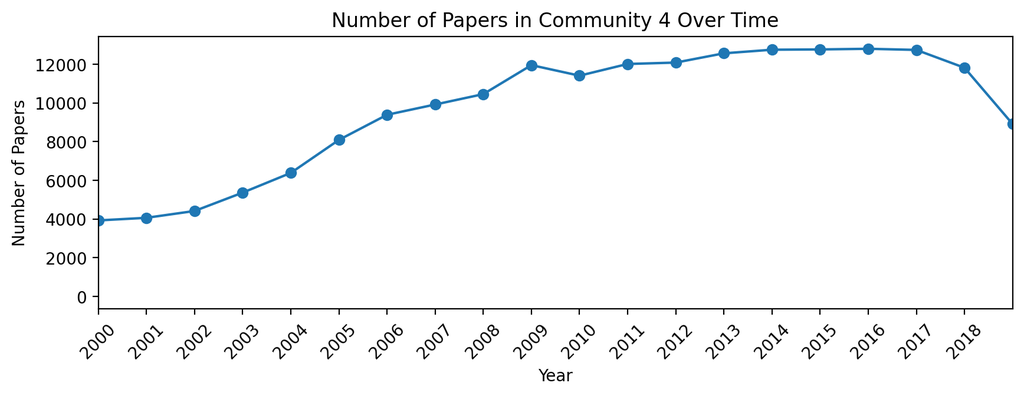

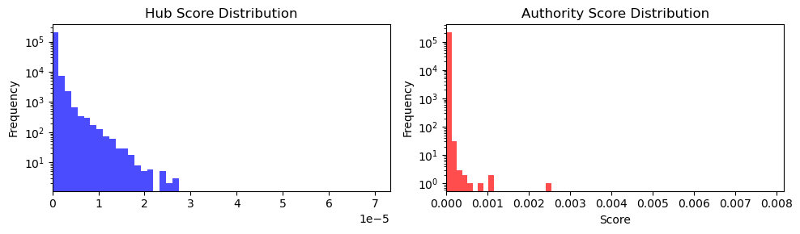

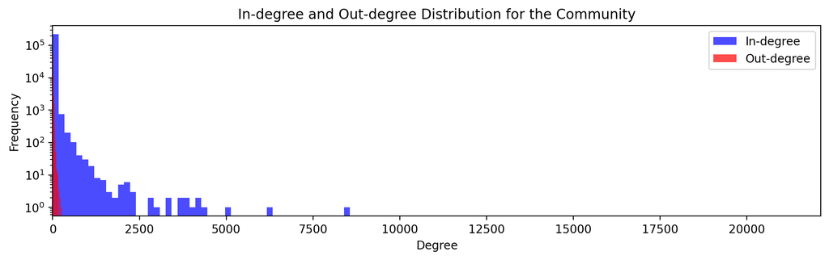

**Top 5 hubs in the community:**

- **Survey on deep learning with class imbalance** - Justin M. Johnson;Taghi M. Khoshgoftaar - *Journal of Big Data* - 2019

- **DECODE: Deep Confidence Network for Robust Image Classification** - Guiguang Ding;Yuchen Guo;Kai Chen;Chaoqun Chu;Jungong Han;Qionghai Dai - *IEEE Transactions on Image Processing* - 2019

- **Learned vs. engineered features for fine-grained classification of aquatic macroinvertebrates** - Ekaterina Riabchenko;Kristian Meissner;Iftikhar Ahmad;Alexandros Iosifidis;Ville Tirronen;Moncef Gabbouj;Serkan Kiranyaz - *International Conference on Pattern Recognition* - 2016

- **Semi-Supervised Image Classification With Self-Paced Cross-Task Networks** - Si Wu;Qiujia Ji;Shufeng Wang;Hau-San Wong;Zhiwen Yu;Yong Xu - *IEEE Transactions on Multimedia* - 2018

- **Multifeature, Sparse-Based Approach for Defects Detection and Classification in Semiconductor Units** - Bashar M. Haddad;Sen Yang;Lina J. Karam;Jieping Ye;Nital S. Patel;Martin W. Braun - *IEEE Transactions on Automation Science and Engineering* - 2018

**Top 5 authorities:**

- **LIBSVM: A library for support vector machines** - Chih-Chung Chang;Chih-Jen Lin - *ACM Transactions on Intelligent Systems and Technology* - 2011

- **Random Forests** - Leo Breiman - *Machine Learning archive* - 2001

- **Support-Vector Networks** - Corinna Cortes;Vladimir Vapnik - *Machine Learning* - 1995

- **The Nature of Statistical Learning Theory** - Vladimir N. Vapnik - *nan* - 1995

- **A decision-theoretic generalization of on-line learning and an application to boosting** - Yoav Freund;Robert E Schapire - *Conference on Learning Theory* - 1997

Biomechanical modeling of skeletal structures and tissues

The primary focus of this research community lies in the computational and mathematical modeling of biomechanical systems, particularly involving bones, joints, and soft tissues. Researchers in this area aim to understand the mechanical properties and behaviors of skeletal structures and biological tissues under various conditions, including injury, disease, and medical treatments. Key problems addressed include stress distribution, fracture fixation, bone remodeling, and cartilage deformation. Methods commonly employed encompass finite element analysis, mathematical modeling, and computational simulations, supplemented by experimental measurements. The ultimate goals are to improve clinical diagnoses, optimize surgical interventions, and enhance the design of medical implants and prostheses to achieve better patient outcomes.  
**Community ID**: 48  
**Number of Papers**: 45

**Coverage index** 0.0

**Growth rate (last 20 years)** 9.3532

**Top 5 hubs in the community:**

- **External fixator configurations in tibia fractures** - Luis M. Roseiro;M. Augusta Neto;Ana Amaro;Rogerio P. Leal;Miguel C. Samarra - *Computer Methods and Programs in Biomedicine* - 2014

- **Determination of nonlinear fibre-reinforced biphasic poroviscoelastic constitutive parameters of articular cartilage using stress relaxation indentation testing and an optimizing finite element analysis** - A. Seifzadeh;D. C. D. Oguamanam;N. Trutiak;M. Hurtig;M. Papini - *Computer Methods and Programs in Biomedicine* - 2012

- **Patient-specific aortic endografting simulation: From diagnosis to prediction** - F. Auricchio;M. Conti;S. Marconi;A. Reali;Jip L. Tolenaar;S. Trimarchi - *Computers in Biology and Medicine* - 2013

- **Tailor-Made Plate Design and Manufacturing System for Treating Bone Fractures in Small Animals** - Akio Doi;Hiroki Takahashi;Bunei Syuto;Masaaki Katayama;Hiroyuki Nagashima;Masahiro Okumura - *Journal of Advanced Computational Intelligence and Intelligent Informatics* - 2013

- **Design and application of tailor-made plates for treating fractures in small animals** - Akio Doi;Hiroki Takahashi;Bunei Shuto;Masaaki Katayama;Hiroyuki Nagashima;Masahiro Okumura - *IEEE International Conference on Adaptive Science & Technology* - 2012

**Top 5 authorities:**

- **The relation between micromotion and screw fixation in acetabular cup** - Jui-Ting Hsu;Kuo-An Lai;Qingshan Chen;Mark E. Zobitz;Heng-Li Huang;Kai-Nan An;Chih-Han Chang - *Computer Methods and Programs in Biomedicine* - 2006

- **Combined multi-body and finite element investigation of the effect of the seat height on acetabular implant stability during the activity of getting up** - Mario Kunze;Andreas Schaller;Hanno Steinke;Roger Scholz;Christian Voigt - *Computer Methods and Programs in Biomedicine* - 2012

- **Robust product design and process planning in using process capability analysis** - Angus Jeang - *Journal of Intelligent Manufacturing* - 2015

- **Development of a volume rendering system using 3D texture compression techniques on general-purpose personal computers** - Akio Doi;Hiroki Takahashi;Taro Mawatari;Sachio Mega - *IEEE International Conference on Adaptive Science & Technology* - 2011

- **Patient-specific aortic endografting simulation: From diagnosis to prediction** - F. Auricchio;M. Conti;S. Marconi;A. Reali;Jip L. Tolenaar;S. Trimarchi - *Computers in Biology and Medicine* - 2013

Advances in survey sampling techniques and estimation methods.

The primary research focus of this community is on survey sampling techniques, particularly in contexts where traditional data collection faces challenges such as missing data, nonresponse, or the need for privacy protection. The researchers are developing and refining various statistical estimators and sampling designs to improve the accuracy and efficiency of population parameter estimates. Key methods include ratio estimators, randomized response techniques, calibration estimation, and model-assisted estimation. These methods aim to handle complexities like nonresponse, stratified sampling, and the incorporation of auxiliary information to mitigate bias and enhance the reliability of survey results. The overarching goal is to optimize data collection and estimation processes, ensuring robust and unbiased findings even under practical constraints and challenging survey conditions.  
**Community ID**: 45  
**Number of Papers**: 69

**Coverage index** 0.0

**Growth rate (last 20 years)** 10.5823

**Top 5 hubs in the community:**

- **A predictive estimator of finite population proportion despite missing data** - María del Mar Rueda;Silvia González;Antonio Arcos - *Applied Mathematics and Computation* - 2014

- **Generalized geometric distribution of order k: A flexible choice to randomize the response** - Zawar Hussain;Javid Shabbir;Zahid Pervez;Said Farooq Shah;Manzoor Khan - *Communications in Statistics - Simulation and Computation* - 2017

- **Randomized response surveys: A note on some privacy protection measures** - Giancarlo Diana;Marco Giordan;Pier Francesco Perri - *Model Assisted Statistics and Applications* - 2013

- **Global Optimization Problems in Optimal Design of Experiments in Regression Models** - E. P. J. Boer;E. M. T. Hendrix - *Journal of Global Optimization* - 2000

- **Case-deletion type diagnostics for calibration estimators in survey sampling** - I. Barranco-Chamorro;M. D. Jiménez-Gamero;J. L. Moreno-Rebollo;J. M. Muñoz-Pichardo - *Computational Statistics & Data Analysis* - 2012

**Top 5 authorities:**

- **Estimation in Surveys with Nonresponse** - Carl-Erik Särndal;Sixten Lundström - *nan* - 2005

- **Ratio estimators in simple random sampling** - Cem Kadilar;Hulya Cingi - *Applied Mathematics and Computation* - 2004

- **Randomized response surveys: A note on some privacy protection measures** - Giancarlo Diana;Marco Giordan;Pier Francesco Perri - *Model Assisted Statistics and Applications* - 2013

- **Optimum allocation in stratified surveys: Stochastic programming** - José A. Díaz-García;Ma. Magdalena Garay-Tápia - *Computational Statistics & Data Analysis* - 2007

- **Global Optimization Problems in Optimal Design of Experiments in Regression Models** - E. P. J. Boer;E. M. T. Hendrix - *Journal of Global Optimization* - 2000